# **Used Cars Price Prediction**

### **Feature Engineering**

**Think about it:** The `Name` column in the current format might not be very useful in our analysis. Since the name contains both the brand name and the model name of the vehicle, the column would have too many unique values to be useful in prediction. Can we extract that information from that column?

- **Hint:** With 2041 unique names, car names are not going to be great predictors of the price in our current data. But we can process this column to extract important information for example brand name.

```python
# Extract Brand Names
data["brand"] = data["name"].apply(lambda x: x.split(" ")[0].lower())
cat_cols.append("brand")
cat_cols.remove("name")
data.head()
```

|  | name | location | year | kilometers_driven | fuel_type | transmission | owner_type | mileage | engine | power | seats | new_price | price | brand |
| --- | --- | --- | --- | --- | --- | --- | --- | --- | --- | --- | --- | --- | --- | --- |
| 0 | Maruti Wagon R LXI CNG | Mumbai | 2010 | 72000 | CNG | Manual | First | 26.60 | 998.0 | 58.16 | 5.0 | 22.779692 | 1.75 | maruti |
| 1 | Hyundai Creta 1.6 CRDi SX Option | Pune | 2015 | 41000 | Diesel | Manual | First | 19.67 | 1582.0 | 126.20 | 5.0 | 22.779692 | 12.50 | hyundai |
| 2 | Honda Jazz V | Chennai | 2011 | 46000 | Petrol | Manual | First | 18.20 | 1199.0 | 88.70 | 5.0 | 8.610000 | 4.50 | honda |
| 3 | Maruti Ertiga VDI | Chennai | 2012 | 87000 | Diesel | Manual | First | 20.77 | 1248.0 | 88.76 | 7.0 | 22.779692 | 6.00 | maruti |
| 4 | Audi A4 New 2.0 TDI Multitronic | Coimbatore | 2013 | 40670 | Diesel | Automatic | Second | 15.20 | 1968.0 | 140.80 | 5.0 | 22.779692 | 17.74 | audi |

Next we need to deal with the skewness of the data in some of the columns that we saw. We will use Log Transformation to help normalize the data. before using those features for developing our model(s).

```python
skewed_cols = ['price', 'new_price','kilometers_driven']
for col in skewed_cols:
    data[col + '_log'] = np.log(data[col] + 1) #Add 1 to avoid taking log of 0
    num_cols.append(col + '_log')
print(num_cols)
```

```
['year', 'kilometers_driven', 'mileage', 'engine', 'power', 'new_price', 'price', 'price_log', 'new_price_log', 'kilometers_driven_log']
```

```python
data.head()
```

|  | name | location | year | kilometers_driven | fuel_type | transmission | owner_type | mileage | engine | power | seats | new_price | price | brand | price_log | new_price_log | kilometers_driven_log |
| --- | --- | --- | --- | --- | --- | --- | --- | --- | --- | --- | --- | --- | --- | --- | --- | --- | --- |
| 0 | Maruti Wagon R LXI CNG | Mumbai | 2010 | 72000 | CNG | Manual | First | 26.60 | 998.0 | 58.16 | 5.0 | 22.779692 | 1.75 | maruti | 1.011601 | 3.168832 | 11.184435 |
| 1 | Hyundai Creta 1.6 CRDi SX Option | Pune | 2015 | 41000 | Diesel | Manual | First | 19.67 | 1582.0 | 126.20 | 5.0 | 22.779692 | 12.50 | hyundai | 2.602690 | 3.168832 | 10.621352 |
| 2 | Honda Jazz V | Chennai | 2011 | 46000 | Petrol | Manual | First | 18.20 | 1199.0 | 88.70 | 5.0 | 8.610000 | 4.50 | honda | 1.704748 | 2.262804 | 10.736418 |
| 3 | Maruti Ertiga VDI | Chennai | 2012 | 87000 | Diesel | Manual | First | 20.77 | 1248.0 | 88.76 | 7.0 | 22.779692 | 6.00 | maruti | 1.945910 | 3.168832 | 11.373675 |
| 4 | Audi A4 New 2.0 TDI Multitronic | Coimbatore | 2013 | 40670 | Diesel | Automatic | Second | 15.20 | 1968.0 | 140.80 | 5.0 | 22.779692 | 17.74 | audi | 2.930660 | 3.168832 | 10.613271 |

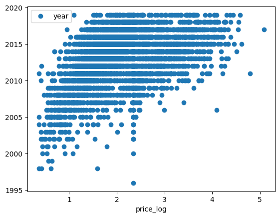

```python
# Let us plot pair plot for the variables 'year' and 'price_log'
data.plot(x = 'price_log', y = 'year', style = 'o')
```

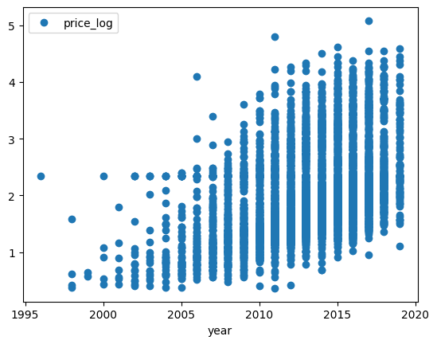

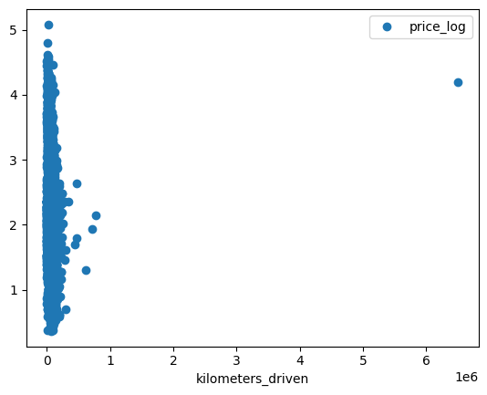

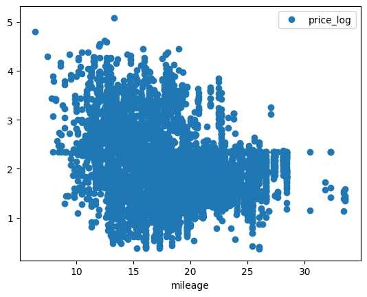

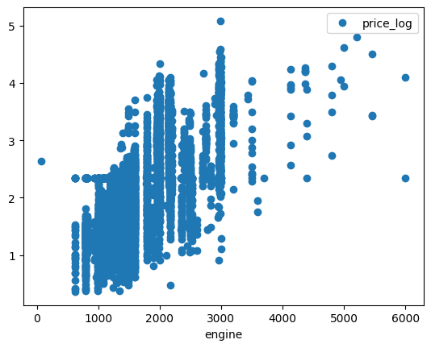

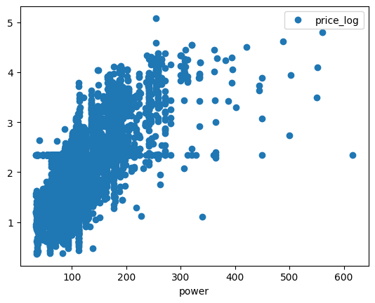

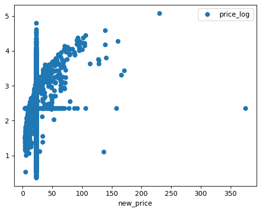

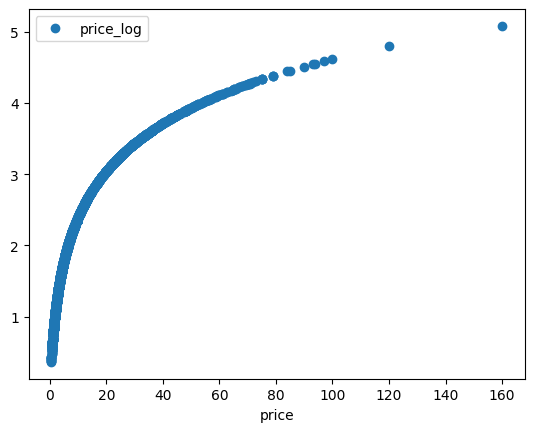

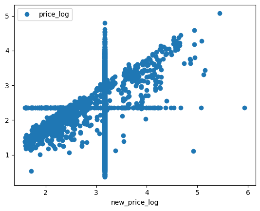

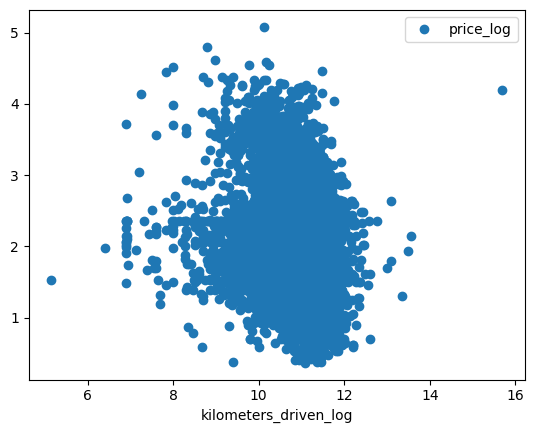

```python
# Next Compare different combinations of independent variables and dependent variables to better understand the relationship between all variables.
num_data = data[num_cols]
for  col in num_data:
    if col != 'price_log':
        data.plot(x = col, y = 'price_log', style = 'o')
```